# Assignment6

Thao Pham

2024-10-21

# Assignment 6: Perceptron Learning Algorithm

## Introduction

Use the Perceptron Learning Algorithm (PLA) to create a linear boundary to help Netflix make future recommendations to Ms. X. Report the model and number of iterations it took for the wights to converge.

Table of Contents:

- Introduction
- Read & examine the data
- Training a perceptron with PLA
- Reporting the model
- Plot of boundary line

## Setup

Importing necessary library for this assignment, `ggplot2` to plot data.

```r
knitr::opts_chunk$set(echo = TRUE, warning = FALSE, message = FALSE)
library(ggplot2)
library(rmarkdown)
```

## Read & examine the data

Importing the movie data from the *movieData.csv* and displaying the content of the file.  
By default, when reading a dataframe, a console message will be displayed. To hide the message, use `show_col_type = FALSE` as a parameter of `read_csv()`. `movies` is created to store the dataset from *movieData.csv*.

```r
# movies = read_csv('movieData.csv', show_col_types = FALSE) # reading movieData.csv
movies = read.csv('../data/movieData.csv') # reading movieData.csv
movies # displaying the data
```

```
##    LevelOfViolence CriticsRating Watched
## 1                1           1.2      -1
## 2                1           3.5       1
## 3                1           4.2       1
## 4                2           3.9       1
## 5                2           2.8      -1
## 6                3           3.0      -1
## 7                5           4.5      -1
## 8                4           1.8      -1
## 9                1           2.1      -1
## 10               3           4.8       1
## 11               5           4.9       1
## 12               3           1.5      -1
## 13               3           2.6      -1
```

**Interpretation of the dataset, `movieData`**

There are 3 columns, *LevelOfViolence*, *CriticsRating* and *Watched*; inside the *movieData.csv* with 13 data.  
- *LevelOfViolence* is numerical variable with values.  
- *CriticsRating* is a continuous variable with values.  
- *Watched* has binary values with -1 as not watch movie and 1 as watched movie.

### Data Visualization

Displaying *Critic Ratings* versus *Level of Violence* and include a way to identify if Ms. X watched it or not.

- `ggplot(movies)`: This creates a new ggplot object using the movies data frame as the base.
- `aes(y=CriticsRating, x=LevelOfViolence, color = factor(Watched))`:
- `y=CriticsRating`: Sets the y-axis to represent the CriticsRating variable.
- `x=LevelOfViolence`: Sets the x-axis to represent the LevelOfViolence variable.
- `color = factor(Watched)`: Maps the Watched variable to the color aesthetic, effectively coloring points based on their Watched status. The factor() function is used to ensure that Watched is treated as a categorical variable.
- `geom_point( size=3)`: Adds scatter plot with the size 3 of the points to the graph.
- `scale_color_manual(values = c("-1" = "red", "1" = "blue") , labels = c("Not Watched", "Watched"))`: Manually specifies the colors for the different levels of the Watched variable.
- `values = c("-1" = "red", "1" = "blue")`: Associates the value “-1” with the color red and the value “1” with the color blue.
- `labels = c("Not Watched", "Watched")`: Replaces the default labels “-1” and “1” with more descriptive labels “Not Watched” and “Watched”.
- `labs(title = "Decision Boundary of Perceptron", color = "Watch Status")`: Setting the title of the graph to “Decision Boundary of Perceptron” and the legend title for the color aesthetic to “Watch Status”.
- `xlab('Critics Rating')`: Setting the label for the x-axis to “Critics Rating”.
- `ylab('Level of Violence')`: Setting the label for the y-axis to “Level of Violence”.

[figure not shown]

```r
ggplot(movies, aes(y=CriticsRating, x=LevelOfViolence, color = factor(Watched))) +
  geom_point( size=3) + # using shape in geom_point parameter
  scale_color_manual(values = c("-1" = "red", "1" = "blue") , labels = c("Not Watched", "Watched")) +
  labs(title = "Decision Boundary of Perceptron", color = "Watch Status") +
  xlab('Critics Rating') +
  ylab('Level of Violence')
```

## Training a perceptron with Perceptron Learning Algorithm

Hard coding for Perceptron Learning Algorithm (PLA).

```r
set.seed(123) # making sure the runif() always return the same values

weights <- runif(ncol(movies), min = -1, max = 1) # generating weights that matches the number of columns in movies
cat('Weights:', weights,'\n') # displaying the weights
```

```
## Weights: -0.424845 0.5766103 -0.1820462
```

```r
new <- cbind(Bias = rep(1, nrow(movies)), as.matrix(movies)) #Attaching the Bias column with the data in movies
new
```

```
##       Bias LevelOfViolence CriticsRating Watched
##  [1,]    1               1           1.2      -1
##  [2,]    1               1           3.5       1
##  [3,]    1               1           4.2       1
##  [4,]    1               2           3.9       1
##  [5,]    1               2           2.8      -1
##  [6,]    1               3           3.0      -1
##  [7,]    1               5           4.5      -1
##  [8,]    1               4           1.8      -1
##  [9,]    1               1           2.1      -1
## [10,]    1               3           4.8       1
## [11,]    1               5           4.9       1
## [12,]    1               3           1.5      -1
## [13,]    1               3           2.6      -1
```

**Interpretation for Initializing Weights and Attaching Bias** By setting the seed to `123`, the `runif()` returns the same values of `weights`, which are -0.4248450, 0.5766103, and -0.1820462. The contents of `new` are Bias, LevelOfViolence, CriticsRating, and Watched with 13 data points.

### Perceptron Learning Algorithm (PLA)

- Iterating until `weights` is converged.
  - Tracking the number of iterations
  - Grabbing a data point and divides it into `inputData`( Bias, LevelOfViolence, and CriticsRating) and `targetData`(Watched).
  - Calculating the net input using the dot product.
  - Apply the activation function using `sign()` to get the predicted values.
  - Comparing the predicted and actual values. If they aren’t equal to each other, update the `weights` vector by multiple the `targetData` with transposed `inputData`, then added with the current `weights`.
- Reporting number of iterations it took for weights to converge.
- Returning the final weights.
- `Sign()`: Returning 1 if the value is greater positive and returning -1 if the value is negative.
- `cat()`: Printing one or more values
- `as.matrix()`: Converting to matrix
- `sum()`: Adding function

```r
# Initialize variables
iterations <- 0 # number of iteration through the loop
converged <- FALSE # condition for the loop


while (!converged )
  {
  converged <- TRUE  # Assume convergence is TRUE until
  incorrect_counts <- 0  # Reset count for each iteration
  iterations <- iterations + 1

  # Loop through each row/data point
  for (i in 1:nrow(movies)) {
    # Separate the inputData and targetData for the current row
    inputData = as.numeric(new[i, 1:3])  # Includes Bias, LevelOfViolence, and CriticsRating
    targetData = as.numeric(new[i, 4])   # Watched label (-1 or 1)

    # Apply the activation function using sign() with dot product
    prediction = sign(sum(inputData * weights))

    # Check if the prediction is incorrect
    if (prediction != targetData) {
      # Update the weights
      weights = weights + targetData * t(as.matrix(inputData))

      # Increment the count of incorrect predictions
      incorrect_counts = incorrect_counts+1
      converged = FALSE
    }
  }
  if (incorrect_counts == 0) {
    cat("Convergence reached.\n")
    break # stop the loop
  }

  # Stop if the number of iterations exceeds a reasonable threshold
  if (iterations > 1000) {
    cat("Exceeded maximum number of iterations. Stopping training.\n")
    break # stop the loop
  }
}
```

```
## Convergence reached.
```

```r
# Output the results
cat("Training completed in", iterations, "iterations.\n")
```

```
## Training completed in 35 iterations.
```

```r
cat("Final weights:", weights, "\n")
```

```
## Final weights: -26.42484 -8.42339 14.21795
```

## Reporting the model

```r
cat("Final weights:", weights, "\n")
```

```
## Final weights: -26.42484 -8.42339 14.21795
```

```r
cat("Number of iterations:", iterations, "\n")
```

```
## Number of iterations: 35
```

```r
# Output the final PLA model
cat("The final model is: Sign(",weights[1], " + ", weights[2], " * x1 + ", weights[3], " * x2)\n")
```

```
## The final model is: Sign( -26.42484  +  -8.42339  * x1 +  14.21795  * x2)
```

```r
# Equation for the decision boundary
cat("Equation: ", weights[2], "* x1 + ", weights[3], "* x2 =", -weights[1], "\n")
```

```
## Equation:  -8.42339 * x1 +  14.21795 * x2 = 26.42484
```

```r
# Calculate slope and y-intercept for visualization
slope = -weights[2] / weights[3]
y_intercept = -weights[1] / weights[3]

cat("Slope:", slope, "\n")
```

```
## Slope: 0.5924474
```

```r
cat("Y-intercept:", y_intercept, "\n")
```

```
## Y-intercept: 1.858555
```

#### Interpretation for Results

The model predicts whether a movie will be watched or not (binary classification). The weights suggest that CriticsRating has a stronger positive influence on whether a movie is watched compared to LevelOfViolence, which has a negative influence. The slope of the decision boundary indicates the trade-off between LevelOfViolence and CriticsRating in determining the classification.

## Plot of boundary line

To plot the boundary line, we need to have the **Slope** and **y-intercept**, both are found above. Adding the **Bias** column is necessary because it accounts for the intercept in the model. In the Perceptron Learning Algorithm (PLA), the bias term allows the decision boundary to shift away from the origin, which helps in fitting the classification model better when the classes are not linearly separable through the origin.

- `theme_minimal()` applies a minimalistic theme to the plot for cleaner aesthetics.
- `geom_abline()` adds a line representing the decision boundary to the plot. This line is defined by a given slope and y_intercept.

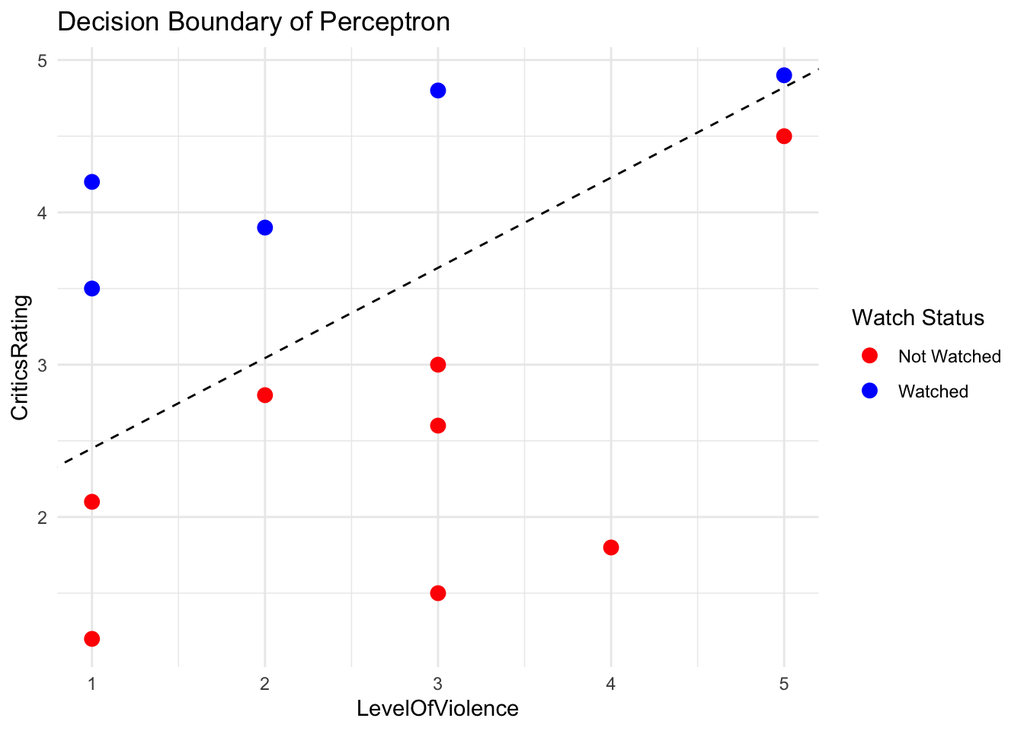

```r
# Convert data to a data frame for plotting
movies$Bias = 1  # Add bias column for plotting purposes

# Plot data points
plot = ggplot(movies, aes(x = LevelOfViolence, y = CriticsRating, color = factor(Watched))) +
  geom_point(size = 3) +
  scale_color_manual(values = c("-1" = "red", "1" = "blue"), labels = c("Not Watched", "Watched")) +
  labs(title = "Decision Boundary of Perceptron", color = "Watch Status") +
  theme_minimal()

# Add decision boundary line to the plot
plot <- plot + geom_abline(slope = slope, intercept = y_intercept, color = "black", linetype = "dashed")

# Display the plot
print(plot)
```

#### Interpretation for Decision Boundary Plot

The decision boundary is a line that separates watched movies from not watched. Movies above the line are predicted to be watched, while those below are predicted not to be.

The accuracy of the model depends on how well the line separates the blue and red points. If there’s a lot of overlap, the model might not be accurate.